# homework3

#### 1.

##### (1) Solution:

Since $log(y)=x^T\beta+\epsilon$, we have $y=exp(x^T\beta+\epsilon)$.  
$\epsilon \sim N(0,\sigma^2) \Rightarrow x^T\beta+\epsilon \sim N(x^T\beta, \sigma^2)$  
Thus, $E(y)=E[exp(x^T\beta+\epsilon)]=exp(x^T\beta+\frac{1}{2}\sigma^2)$

##### (2)

##### (2.1) Solution:

$\frac{\partial Q(\beta)}{\partial \beta}=2(X^TX\beta -X^Ty +\lambda \beta)$  
Let $X^TX\beta +\lambda \beta = X^Ty$, we have $\widehat \beta_{ridge} =(X^TX + \lambda I_p)^{-1}X^Ty$

##### (2.2) Solution:

$E(\widehat \beta_{ridge})=E((X^TX + \lambda I_p)^{-1}X^Ty)=E((X^TX + \lambda I_p)^{-1}X^T(X\beta + \epsilon))=(X^TX + \lambda I_p)^{-1}X^TX\beta$  
$Bias(\widehat \beta_{ridge}) = E(\widehat \beta_{ridge}) - \beta = [(X^TX + \lambda I_p)^{-1}X^TX-I_p]\beta=-\lambda(X^TX +\lambda I_p)^{-1}\beta$  
Let $-\lambda(X^TX + \lambda I_p)^{-1}\beta=0$, we have $\lambda = 0$ or $\beta = \vec{0}$

##### (2.3) Solution:

When $\lambda = 0$, $MSE(\widehat \beta_{ridge,0}) = [Bia(\widehat \beta_{ridge,0})]^2 + Var(\widehat \beta_{ridge,0}) =Var(\widehat \beta_{ridge,0}) > Var(\widehat \beta_{ridge})$  
Thus, $\widehat \beta_{ridge,0}$ may not the estimator that minimizes MSEs among all the Ridge estimators.

#### 2.

```python
'(1)'
import pandas as pd

traindata = pd.read_csv('sampledata.csv')
testdata = pd.read_csv('preddata.csv')
```

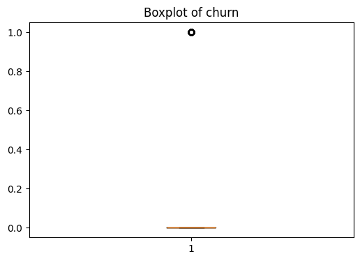

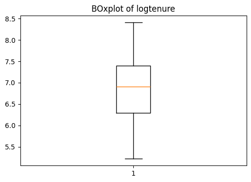

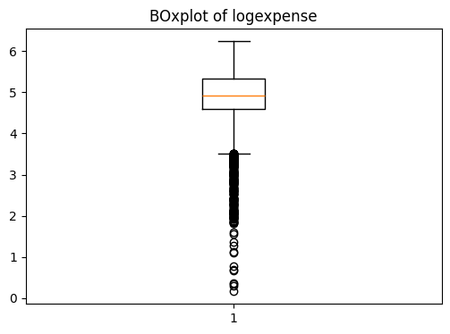

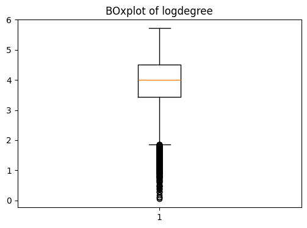

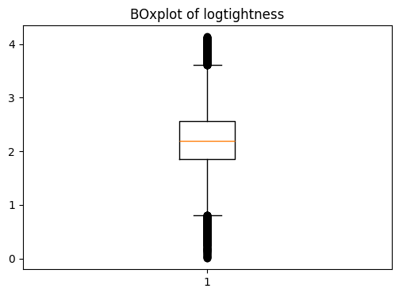

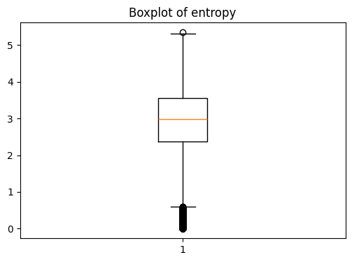

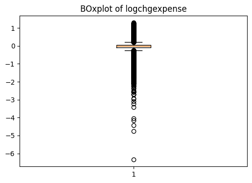

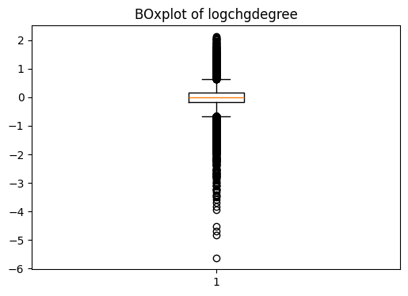

```python
'(2)'
import matplotlib.pyplot as plt
import numpy as np

headers = traindata.columns.tolist()
independents = [header for header in headers]
independents.remove('ID')
independents.remove('churn')

plt.figure(figsize = (6, 4))
plt.boxplot(x = 'churn', data = traindata)
plt.title('Boxplot of churn')
plt.show()

for ind in independents:
    plt.figure(figsize = (6, 4))
    if traindata[ind].skew() > 1:
        data_to_plot = np.log1p(traindata[ind])
        plt.title(f'BOxplot of log{ind}')
    else:
        data_to_plot = traindata[ind]
        plt.title(f'Boxplot of {ind}')
    plt.boxplot(data_to_plot)
    plt.show()
```

```python
'(3)'
from sklearn.preprocessing import StandardScaler
from sklearn.linear_model import LogisticRegression

X_train = traindata[independents]
Y_train = traindata['churn']
scaler = StandardScaler()
X_train_scaler = scaler.fit_transform(X_train)

log_model = LogisticRegression()
log_model.fit(X_train_scaler, Y_train)

print("The parameters of LogisticRegression:")
print('intercept:', log_model.intercept_)
print("coefficient:",log_model.coef_)
```

```
The parameters of LogisticRegression:
intercept: [-5.05254042]
coefficient: [[-0.24852142 -0.28688144 -0.74192554 -0.22724613 -0.35565462 -0.15582322
  -0.38253509]]
```

系数为正说明该自变量与客户流失正相关，系数为负说明该自变量与客户流失负相关，绝对值大小表示相关程度。

```python
'(4)'
X_test = testdata[independents]
Y_test = testdata['churn']
X_test_scaler = scaler.fit_transform(X_test)

train_pre = log_model.predict_proba(X_train_scaler)
test_pre = log_model.predict_proba(X_test_scaler)

print('The prediction of churn probability (Train):')
print(f'{train_pre}')
print("The prediction of churn probability (Test):")
print(f'{test_pre}')
```

```
The prediction of churn probability (Train):
[[9.95018527e-01 4.98147267e-03]
 [9.89341231e-01 1.06587691e-02]
 [9.96563215e-01 3.43678474e-03]
 ...
 [9.99177426e-01 8.22574263e-04]
 [9.97407823e-01 2.59217682e-03]
 [9.91613075e-01 8.38692474e-03]]
The prediction of churn probability (Test):
[[9.67007381e-01 3.29926188e-02]
 [9.93728952e-01 6.27104768e-03]
 [9.91450912e-01 8.54908788e-03]
 ...
 [9.99480943e-01 5.19057058e-04]
 [9.98539199e-01 1.46080125e-03]
 [9.91999595e-01 8.00040489e-03]]
```

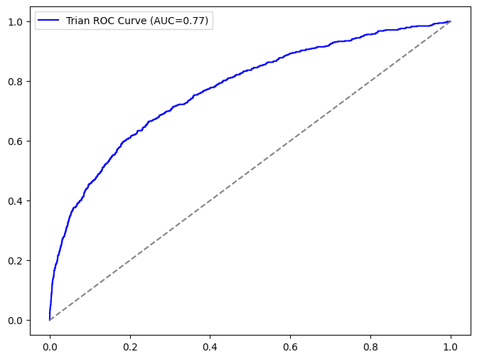

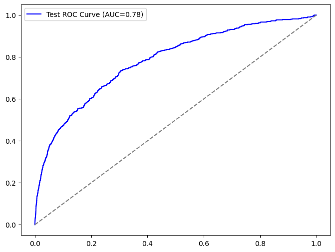

```python
'(5)'
from sklearn.metrics import roc_curve, auc
fpr_train, tpr_train, _ = roc_curve(Y_train, train_pre[:, 1])
auc_train = auc(fpr_train, tpr_train)

fpr_test, tpr_test, _ = roc_curve(Y_test, test_pre[:, 1])
auc_test = auc(fpr_test, tpr_test)

plt.figure(figsize=(8, 6))
plt.plot(fpr_train, tpr_train, color = 'blue', label = f'Trian ROC Curve (AUC={auc_train:.2f})')
plt.plot([0, 1], [0, 1], color = 'gray', linestyle = '--')
plt.xlabel = 'False Positive Rate'
plt.ylabel = 'True Positive Rate'
plt.legend()
plt.show()

plt.figure(figsize=(8, 6))
plt.plot(fpr_test, tpr_test, color = 'blue', label = f'Test ROC Curve (AUC={auc_test:.2f})')
plt.plot([0, 1], [0, 1], color = 'gray', linestyle = '--')
plt.xlabel = 'False Positive Rate'
plt.ylabel = 'True Positive Rate'
plt.legend()
plt.show()
```

训练集和测试集的AUC和ROC曲线都比较接近，说明模型拟合效果较好，没有出现比较大的过拟合现象，AUC>0.5，说明没有出现欠拟合的现象，模型总体表现较好。